# Hypothesis Testing: Comparing Categorical Variables

Author

Global Health and Infectious Diseases Group - KCCR-KNUST, Ghana for ISARIC

## Hypothesis Testing: Comparing Categorical Variables

While the t-test compares means between groups, the **chi-squared test** compares **proportions** or **distributions** of categorical variables across groups. Common questions include: “Does mortality rate differ between males and females?” or “Is there an association between treatment group and outcome?”

### The Chi-Squared Test Framework

The chi-squared test ($\chi^2$ test) evaluates whether the observed frequencies in a contingency table differ significantly from expected frequencies under independence:

- **Null Hypothesis ($H_0$)**: The two variables are **independent** (no association)
- **Alternative Hypothesis ($H_1$)**: The two variables are **associated** (not independent)
- **Test Statistic**: $\chi^2 = \sum \frac{(\text{Observed} - \text{Expected})^2}{\text{Expected}}$
- **P-value**: Probability of observing data this extreme if $H_0$ is true

**When to Use Chi-Squared**: - Comparing **proportions** between two or more categorical groups - Testing **association** between two categorical variables - Data organized in a **contingency table** (cross-tabulation) - Expected cell counts ≥ 5 in most cells

## Setting Up the Environment

We’ll analyze whether there is an association between sex (Male/Female) and patient outcome (Discharged/Death). This is a practical clinical question: do males and females have different mortality rates in this patient population?

We’ll create a 2×2 contingency table and use the chi-squared test to evaluate independence.

```r
# Load the synthetic dataset
df <- read.csv(
  "https://raw.githubusercontent.com/EstebanGarciaG/Lectures/main/data/data_synth.csv"
)

df2 <- subset(
  df,
  demog_sex %in%
    c("Male", "Female") &
    outco_binary_outcome %in% c("Discharged", "Death") &
    demog_sex != "" &
    outco_binary_outcome != ""
)

paste("Dataset prepared:")
```

```
[1] "Dataset prepared:"
```

```r
paste("Total observations (after filtering):", nrow(df2))
```

```
[1] "Total observations (after filtering): 882"
```

```r
paste("Variables: Sex (Male/Female), Outcome (Discharged/Death)")
```

```
[1] "Variables: Sex (Male/Female), Outcome (Discharged/Death)"
```

**Data Filtering**: We keep only complete cases for sex (Male/Female) and outcome (Discharged/Death). This excludes censored or missing observations, ensuring clean data for our 2×2 contingency table.

## Creating the Contingency Table

A **contingency table** (also called a cross-tabulation) displays the joint frequency distribution of two categorical variables.

### Basic Contingency Table

```r
df2$outco_binary_outcome <- factor(
  df2$outco_binary_outcome,
  levels = c("Discharged", "Death")
)

tab_sex_mortality <- table(
  Sex = df2$demog_sex,
  Outcome = df2$outco_binary_outcome
)

paste("--- Contingency Table (Raw Counts) ---")
```

```
[1] "--- Contingency Table (Raw Counts) ---"
```

```r
tab_sex_mortality
```

```
        Outcome
Sex      Discharged Death
  Female        373    36
  Male          418    55
```

**Factor Conversion**: We convert the outcome to a factor with ordered levels (Discharged first, Death second). This ensures proper handling in statistical models and controls the reference category for regression analyses.

### Contingency Table with Totals

```r
# Add row and column margins (totals)
tab_with_margins <- addmargins(tab_sex_mortality)

paste("--- Contingency Table with Row and Column Totals ---")
```

```
[1] "--- Contingency Table with Row and Column Totals ---"
```

```r
tab_with_margins
```

```
        Outcome
Sex      Discharged Death Sum
  Female        373    36 409
  Male          418    55 473
  Sum           791    91 882
```

**Warning**

**Reading the Table**: - Each cell contains the count of observations in that category combination - Row totals show how many males/females overall - Column totals show how many were discharged/died overall - The bottom-right cell is the grand total (N)

## Calculating Proportions and Rates

Understanding proportions helps visualize the relationship before formal testing:

```r
# Calculate mortality rate within each sex
male_total <- sum(tab_sex_mortality["Male", ])
female_total <- sum(tab_sex_mortality["Female", ])
male_deaths <- tab_sex_mortality["Male", "Death"]
female_deaths <- tab_sex_mortality["Female", "Death"]

male_mortality_rate <- male_deaths / male_total
female_mortality_rate <- female_deaths / female_total

paste("--- Mortality Rates by Sex ---")
```

```
[1] "--- Mortality Rates by Sex ---"
```

```r
paste(sprintf(
  "Males:   %d deaths out of %d (%.1f%%)",
  male_deaths,
  male_total,
  male_mortality_rate * 100
))
```

```
[1] "Males:   55 deaths out of 473 (11.6%)"
```

```r
paste(sprintf(
  "Females: %d deaths out of %d (%.1f%%)",
  female_deaths,
  female_total,
  female_mortality_rate * 100
))
```

```
[1] "Females: 36 deaths out of 409 (8.8%)"
```

```r
paste(sprintf(
  "Difference: %.1f percentage points",
  (male_mortality_rate - female_mortality_rate) * 100
))
```

```
[1] "Difference: 2.8 percentage points"
```

## The Chi-Squared Test

### Concept and Assumptions

The chi-squared test compares **observed frequencies** (what we see in the data) to **expected frequencies** (what we’d expect if variables were independent).

**Assumptions**: 1. **Independence of observations**: Each observation belongs to only one cell 2. **Minimum expected frequencies**: Generally, expected counts should be ≥ 5 in most cells 3. **Adequate sample size**: Typically n ≥ 20 for 2×2 tables

### Performing the Chi-Squared Test

```r
chi <- chisq.test(tab_sex_mortality, correct = FALSE)

chi
```

```
    Pearson's Chi-squared test

data:  tab_sex_mortality
X-squared = 1.8931, df = 1, p-value = 0.1689
```

**Yates Correction**: We use `correct = FALSE` for teaching clarity. The Yates continuity correction is conservative (makes it harder to reject H₀). In practice, many statisticians omit it for larger samples. See your field’s conventions.

### Examining Expected Frequencies

Before interpreting results, verify that the chi-squared test assumptions are met:

```r
paste("--- Expected Frequencies ---")
```

```
[1] "--- Expected Frequencies ---"
```

```r
chi$expected
```

```
        Outcome
Sex      Discharged    Death
  Female   366.8016 42.19841
  Male     424.1984 48.80159
```

```r
min_expected <- min(chi$expected)
paste(sprintf("Minimum expected frequency: %.2f", min_expected))
```

```
[1] "Minimum expected frequency: 42.20"
```

```r
if (min_expected >= 5) {
  paste("✓ All expected frequencies are ≥ 5 (assumption satisfied)")
} else {
  paste(
    "⚠ Warning: Some expected frequencies < 5 (consider Fisher's exact test)"
  )
}
```

```
[1] "✓ All expected frequencies are ≥ 5 (assumption satisfied)"
```

**Warning**

**Assumption Check**: The chi-squared test requires expected frequencies ≥ 5 in most cells. If this assumption is violated, use Fisher’s exact test instead, which is exact and doesn’t rely on this approximation.

**Expected Frequencies**: These represent how many observations we’d expect in each cell if sex and outcome were completely independent. Large differences between observed and expected frequencies suggest association.

Formula: $E_{ij} = \frac{(\text{Row Total}_i) \times (\text{Column Total}_j)}{\text{Grand Total}}$

## Interpreting the Results

```r
chi_stat <- chi$statistic
df_chi <- chi$parameter
p_val <- chi$p.value

paste("--- Chi-Squared Test Results ---")
```

```
[1] "--- Chi-Squared Test Results ---"
```

```r
paste(sprintf("χ² statistic: %.4f", chi_stat))
```

```
[1] "χ² statistic: 1.8931"
```

```r
paste(sprintf("Degrees of freedom: %d", df_chi))
```

```
[1] "Degrees of freedom: 1"
```

```r
paste(sprintf("p-value: %.4f", p_val))
```

```
[1] "p-value: 0.1689"
```

```r
alpha <- 0.05
if (p_val < alpha) {
  decision <- "REJECT the null hypothesis"
  interpretation <- "There IS statistically significant evidence of an association between sex and mortality outcome."
} else {
  decision <- "FAIL TO REJECT the null hypothesis"
  interpretation <- "There is NOT sufficient evidence of an association between sex and mortality outcome."
}

paste(sprintf("Decision (α = 0.05): %s", decision))
```

```
[1] "Decision (α = 0.05): FAIL TO REJECT the null hypothesis"
```

```r
paste(sprintf("Interpretation: %s", interpretation))
```

```
[1] "Interpretation: There is NOT sufficient evidence of an association between sex and mortality outcome."
```

**Warning**

**P-value Interpretation**: - If p < 0.05: We reject $H_0$ and conclude there IS a statistically significant association - If p ≥ 0.05: We fail to reject $H_0$; we don’t have enough evidence to conclude there’s an association

Remember: Failing to reject $H_0$ doesn’t prove no association exists—it just means we don’t have sufficient evidence from this data.

## Effect Size: Odds Ratio

The p-value tells us whether an association exists, but the **odds ratio (OR)** quantifies the strength of that association. We’ll examine the odds of discharge vs. death, separately for each sex:

| Group | Odds of Discharge (vs. Death) |
| --- | --- |
| Males | 7.600 |
| Females | 10.361 |
| **Odds Ratio (Males/Females)** | **0.734** |

**What This Means**:

- An **odds of discharge = 2.5** means for every 1 death, there are 2.5 discharges
- The **odds ratio compares these ratios** between sexes
- If OR = 1.2: Males have 20% higher odds of discharge (vs. death) compared to females
- If OR < 1: Females have better odds of discharge (vs. death)

**Understanding Odds Ratio**: - OR = 1: No difference between groups - OR > 1: First group has higher odds of the outcome - OR < 1: First group has lower odds of the outcome - OR = 2 means “twice the odds” (100% higher odds)

The OR is easier to interpret than raw frequencies and is commonly reported in clinical research.

## Visualization: Stacked Bar Chart

A visual representation of the contingency table makes patterns easier to see:

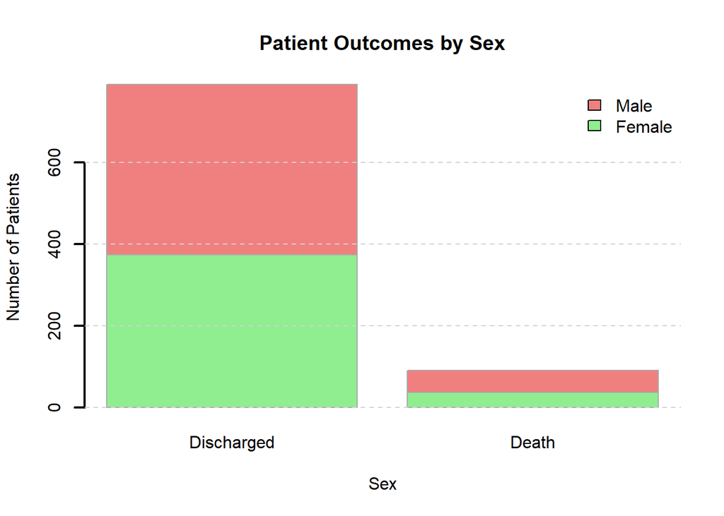

```r
colors <- c("Discharged" = "lightgreen", "Death" = "lightcoral")

barplot(
  tab_sex_mortality,
  main = "Patient Outcomes by Sex",
  xlab = "Sex",
  ylab = "Number of Patients",
  col = colors,
  legend.text = TRUE,
  args.legend = list(x = "topright", bty = "n"),
  border = "darkgray",
  lwd = 2
)

grid(nx = NA, ny = NULL, col = "lightgray", lty = 2)
```

## Alternative: Fisher’s Exact Test

If expected frequencies are too small (< 5), the chi-squared test may not be reliable. Use **Fisher’s exact test** instead:

| Situation | Test to Use |
| --- | --- |
| Expected cell counts ≥ 5 | **Chi-squared test** |
| Expected cell counts < 5 | **Fisher’s exact test** |
| Small sample (n < 20) | **Fisher’s exact test** |

**Code**: `fisher_result <- fisher.test(tab_sex_mortality)`

Fisher’s test is more conservative but provides exact p-values for small samples.

## Key Takeaways

**Warning**

1. **Chi-squared tests categorical associations**: Use for comparing proportions or testing independence between categorical variables.
2. **Always examine the contingency table**: Look at raw counts and proportions before formal testing.
3. **Check assumptions**: Verify that most expected cell counts are ≥ 5. Use Fisher’s exact test for small expected counts.
4. **Report both p-value and effect size**: The p-value tells you IF an association exists; the odds ratio tells you HOW STRONG it is.
5. **Causation ≠ association**: A significant chi-squared test shows association, not causation. Sex doesn’t “cause” mortality differences; other factors (physical differences, comorbidities, etc.) may explain both.
6. **Clinical vs. statistical significance**: Statistical significance (p < 0.05) doesn’t guarantee clinical importance. Consider whether the effect size (OR) is meaningful.

Most of the examples in this section require a lot of manual coding and calculations. In R, specialized packages streamline these tasks significantly:

**Helpful Packages**: - **`epitools`** — Calculate odds ratios and confidence intervals directly from contingency tables - **`gtsummary`** — Create publication-ready summary tables and perform chi-squared tests with single-function calls

```r
library(epitools)
library(gtsummary)
```

```r
odds_ratio_result <- oddsratio(tab_sex_mortality)
odds_ratio_result
```

```
$data
        Outcome
Sex      Discharged Death Total
  Female        373    36   409
  Male          418    55   473
  Total         791    91   882

$measure
        odds ratio with 95% C.I.
Sex      estimate     lower    upper
  Female 1.000000        NA       NA
  Male   1.360898 0.8766628 2.136464

$p.value
        two-sided
Sex      midp.exact fisher.exact chi.square
  Female         NA           NA         NA
  Male    0.1706247    0.1837188  0.1688572

$correction
[1] FALSE

attr(,"method")
[1] "median-unbiased estimate & mid-p exact CI"
```

```r
glm(outco_binary_outcome ~ demog_sex, data = df2, family = binomial) |>
  tbl_regression(exponentiate = TRUE, label = list(demog_sex ~ "Sex"))
```

| **Characteristic** | **OR** | **95% CI** | **p-value** |
| --- | --- | --- | --- |
| Sex |  |  |  |
| Female | — | — |  |
| Male | 1.36 | 0.88, 2.14 | 0.2 |

Abbreviations: CI = Confidence Interval, OR = Odds Ratio

### When to Use Chi-Squared vs. Other Tests

| Situation | Test |
| --- | --- |
| Two **categorical** variables | **Chi-squared** or Fisher’s exact |
| One **categorical** (2 groups), one **continuous** | **t-test** |
| One **categorical** (3+ groups), one **continuous** | **ANOVA** |
| Both variables **continuous** | **Correlation/Regression** |